# Notebook 1: Data Processing

# 1 Data Overview

This file contains the R code used for the computational analysis of [paper name]. We performed LOPIT-DC in 3T3-L1 adipocytes (mouse adipocyte cell line) to determine changes in protein localisation in response to acute insulin and CL316,243 (B3-AR agonist) stimulation.

# 2 Install and load packages

Install R packages needed for data processing -

```r
if (!require("BiocManager", quietly = TRUE)) {
install.packages("BiocManager")
}

BiocManager::install(c("pRoloc",
                       "MSnbase",
                       "pRolocGUI",
                       "tidyverse",
                       "patchwork",
                       "gridExtra",
                       "colorspace",
                       "gplots",
                       "kableExtra",
                       "here",
                       "VennDiagram",
                       "biobroom",
                       "archive",
                       "eulerr",
                       "RColorBrewer"))
```

Load R packages -

```r
library("pRoloc")
library("MSnbase")
library("pRolocGUI")
library("tidyverse")
library("patchwork")
library("gridExtra")
library("colorspace")
library("gplots")
library("kableExtra")
library("here")
library("VennDiagram")
library("biobroom")
library("archive")
library("eulerr")
library("RColorBrewer")
```

Load functions used in data processing -

```r
source(here("1_data_analysis/R/prettymap.R"))
source(here("1_data_analysis/R/getpsms.R"))
source(here("1_data_analysis/R/Utility.R"))
```

# 3 Data processing

In this code chunk we read in the data using the function `parse_features` to pass the output .txt file output from the Proteome Discoverer software which contains the PSM level data. This function reads the PSMs into R and performs filtering against the file `cRAP_FullIdentifiers.fasta` which is an in-house curated contaminants file derived from the cRAP database (ref).

```r
f <- here("1_data_analysis/data/adipocyte_lopit_PSMs.txt.tar.gz")
res <- parse_features(infile = f,
                     crap_fasta = here("1_data_analysis/R/cRAP_FullIdentifiers.fasta"),
                     TMT = TRUE,
                     level="PSM",
                     filter_associated_crap = TRUE,
                     protein_group_col = "X..Protein.Groups")
```

## 3.1 Non-specific filtering

- Check we have no PSMs which lack quantitative data.

```r
table(res$Quan.Info)
torm <- which(res$Quan.Info == "NoQuanLabels")
```

- Check PSMs are unique i.e. PSMs where “Number.of.Protein.Groups” is equal to 1.

```r
table(res$Number.of.Protein.Groups)
```

- Remove peptides with “Rank” or “Search Engine Rank” > 1

```r
(table(res$Rank))
ind <- which(res$Rank > 1)
res <- res[-ind, ]

(table(res$Search.Engine.Rank))
ind <- which(res$Search.Engine.Rank > 1)
res <- res[-ind, ]
```

- Check peptides with no accession number have been removed

```r
which(res$Protein.Accessions == "")
which(res$Master.Protein.Accessions == "")
```

- Double check all contaminants have been removed

```r
crap <- grep("CRAP", res$Protein.Accessions,
             ignore.case = TRUE)
length(crap)
```

## 3.2 Create the MSnSet data structures

- Create a MSnSet

```r
quant_x <- as.matrix(res[, grep("Abundance", colnames(res))])
fdata_x <- AnnotatedDataFrame(res[, -grep("Abundance", colnames(res))])
psms <- MSnSet(exprs = quant_x, fData = fdata_x, stringsAsFactors = FALSE)
```

- Split by Spectrum.File which identified each experiment

```r
sf <- fData(psms)$Spectrum.File
```

- Split by condition

```r
basal <- psms[grep("Basal", sf),  ]
insulin <- psms[grep("Insulin", sf),  ]
```

- Split by replicate

```r
## basal replicates
b_sf <- fData(basal)$Spectrum.File
names(table(b_sf))
basal_r1 <- basal[grep("P973", b_sf), ]
basal_r2 <- basal[grep("_2_", b_sf), ]
basal_r3 <- basal[grep("_3_", b_sf), ]

dim(basal_r1) # 50579 PSMs
dim(basal_r2) # 58716 PSMs
dim(basal_r3) # 56192 PSMs

## insulin replicates
i_sf <- fData(insulin)$Spectrum.File
names(table(i_sf))
insulin_r1 <- insulin[grep("P973", i_sf), ]
insulin_r2 <- insulin[grep("_2_", i_sf), ]
insulin_r3 <- insulin[grep("_3_", i_sf), ]

dim(insulin_r1) # 54566 PSMs
dim(insulin_r2) # 60567 PSMs
dim(insulin_r3) # 57958 PSMs
```

- Make into MSnSet List Make these 3 replicates into an `MSnSetList` for ease of coding.

```r
basal_psms <- MSnSetList(list(basal_r1, basal_r2, basal_r3))
insulin_psms <- MSnSetList(list(insulin_r1, insulin_r2, insulin_r3))
```

- Add experiment data to each MSnSet Here we add `phenoData` also called `pData`, which stores experimental information e.g. replicates, treatments, fraction information, TMT information etc.

```r
# function to add pData to out MSnSets in the MSnSetList
makepdata <- function(msnset,
                      tr,      ## treatment/time (if any)
                      repInfo) {
  tmtID <- function(x) strsplit(sampleNames(msnset), "Abundance..")[[x]][2]
  tmtTag <- sapply(seq(1:ncol(msnset)), function(x) tmtID(x))
  pData(msnset)$Tag <- tmtTag
  pData(msnset)$Treatment <- tr
  pData(msnset)$Replicate <- repInfo
  sampleNames(msnset) <- paste0(tmtTag, "_", tr, "_rep", repInfo)
return(msnset)
}

## Now add the pData
for (i in 1:length(basal_psms))
  basal_psms@x[[i]] <- makepdata(basal_psms[[i]], tr = "Basal", repInfo = i)

for (i in 1:length(insulin_psms))
  insulin_psms@x[[i]] <- makepdata(insulin_psms[[i]], tr = "Insulin", repInfo = i)
```

### 3.2.1 Add more PSM information to MSnSets

- `getPSMsCount` = counts the number of PSMs which have the same aa sequence (column name in fData: “PSM.count”)
- `recordPSMsNA` = the number of number of missing values each PSM has across the fractions (column name in fData: “PSM.count.na”)
- `maxPSMsNA` = the max number of missing values i.e. if we have 3 PSMs for a protein group and 2 have 1 missing values, and 1 has no missing values, we record 1 as the max (so missing value information is not lost when combining to peptide/protein (column name in fData: “PSM.count.na.max”)

```r
## adding getPSMscount
basal_psms <- lapply(basal_psms, getPSMsCount)
insulin_psms <- lapply(insulin_psms, getPSMsCount)

## adding recordPSMsNA
basal_psms <- lapply(basal_psms, recordPSMsNA)
insulin_psms <- lapply(insulin_psms, recordPSMsNA)

## adding maxPSMsNA
basal_psms <- lapply(basal_psms, maxPSMsNA)
insulin_psms <- lapply(insulin_psms, maxPSMsNA)
```

- Show number of PSMs per experiment

```r
paste("Basal PSMs in rep", 1:3, "is", sapply(basal_psms, nrow))
```

```
## [1] "Basal PSMs in rep 1 is 50579" "Basal PSMs in rep 2 is 58716"
## [3] "Basal PSMs in rep 3 is 56192"
```

```r
paste("Insulin PSMs in rep", 1:3, "is", sapply(insulin_psms, nrow))
```

```
## [1] "Insulin PSMs in rep 1 is 54566" "Insulin PSMs in rep 2 is 60567"
## [3] "Insulin PSMs in rep 3 is 57958"
```

# 4 Missing values and imputation

By plotting the number of missing values (MVs) per PSM we see we have very few missing values at the PSM level. We choose to remove any PSM with >3 missing values across each 10plex experiment. Any PSMs with 3 or less MVs are further examined and if these PSMs are (i) the only quantitation for a given protein i.e. single protein hits, or (ii) there is other PSM support available for the corresponding protein group. If there is other support available any PSM with a missing value is removed and not used. The remaining few PSMs which are quantitation for single protein hits are assessed and taken forward for imputation. For the basal condition this is 177, 55 and 50 PSMs out of a total of 40048, 55725 and 52808 PSMs for replicates 1, 2 and 3. Similarly, for the insulin condition this is 93, 50, 56 PSMs out of a total of 54566, 60567, 57958 PSMs for replicates 1, 2 and 3. In all cases this accounts for less than 1% of each PSM population.

### 4.0.1 Basal

Evaluate PSMs with MVs

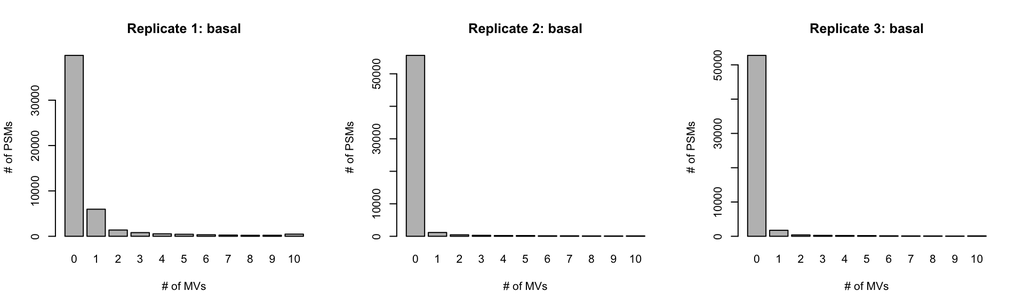

```r
mv_basal <- lapply(basal_psms, function(z) table(fData(z)[["PSM.count.na"]]))

par(mfrow = c(1, 3))
for (i in seq_along(mv_basal))
     barplot(mv_basal[[i]], xlab = "# of MVs",
             ylab = "# of PSMs", main = paste0("Replicate ", i, ": basal"))
```

First we choose to remove all that have more than 3 missing values

```r
for (i in seq(basal_psms)) {
  ind <- which(fData(basal_psms[[i]])$PSM.count.na > 3)
  if (length(ind) > 0) basal_psms@x[[i]] <- basal_psms@x[[i]][-ind, ]
}
```

In the below code we examine the protein group of each PSM which has a missing value, and find that in many cases there are other PSMs available that can be used for quantitation so these PSMs can just be removed.

```r
## Examine which protein groups have peptides with missing values
xx <- lapply(basal_psms, function(x) which(fData(x)[["PSM.count.na"]] != 0))
numpeps <- sapply(seq(basal_psms), function(y) {
  sapply(fData(basal_psms[[y]])$Master.Protein.Accessions[xx[[y]]],
  function(z) length(which(fData(basal_psms[[y]])$Master.Protein.Accessions== z)))})

## single pep hits with a NA
singletons_withNA <- sapply(seq(xx), function(i) xx[[i]][which(numpeps[[i]] == 1)])

## all other basal_psms with a NA
others_withNA <- sapply(seq(xx), function(i) xx[[i]][which(numpeps[[i]] != 1)])

for (i in seq(basal_psms)) {
  basal_psms@x[[i]] <- basal_psms@x[[i]][-others_withNA[[i]], ]
}
```

### 4.0.2 Insulin

We repeat the above for the insulin condition.

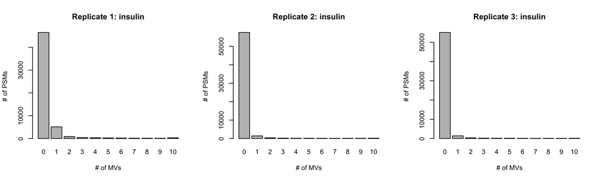

```r
mv_insulin <- lapply(insulin_psms, function(z) table(fData(z)[["PSM.count.na"]]))

par(mfrow = c(1, 3))
for (i in seq_along(mv_insulin))
     barplot(mv_insulin[[i]], xlab = "# of MVs",
             ylab = "# of PSMs", main = paste0("Replicate ", i, ": insulin"))
```

```r
for (i in seq(insulin_psms)) {
  ind <- which(fData(insulin_psms[[i]])$PSM.count.na > 3)
  if (length(ind) > 0) insulin_psms@x[[i]] <- insulin_psms@x[[i]][-ind, ]
}

## Examine which protein groups have peptides with missing values
xx <- lapply(insulin_psms, function(x) which(fData(x)[["PSM.count.na"]] != 0))
numpeps <- sapply(seq(insulin_psms), function(y){
  sapply(fData(insulin_psms[[y]])$Master.Protein.Accessions[xx[[y]]],
  function(z) length(which(fData(insulin_psms[[y]])$Master.Protein.Accessions== z)))})

## single pep hits with a NA
singletons_withNA <- sapply(seq(xx), function(i) xx[[i]][which(numpeps[[i]] == 1)])

## all other insulin_psms with a NA
others_withNA <- sapply(seq(xx), function(i) xx[[i]][which(numpeps[[i]] != 1)])

## Remove insulin_psms with a NA that are NOT single pep hits
## as we can use the other data for quantitation
for (i in seq(insulin_psms)) {
  insulin_psms@x[[i]] <- insulin_psms@x[[i]][-others_withNA[[i]], ]
}
```

- Missing values always tend to appear in the first or last fractions thus we choose a left censored imputation approach for these few PSMs.

```r
basal_psms <- lapply(basal_psms, function(z)
  MSnbase::impute(z, method = "MinDet"))

insulin_psms <- lapply(insulin_psms, function(z)
  MSnbase::impute(z, method = "MinDet"))
```

# 5 Aggregation

For LOPIT we always use all PSMs for quantification, as otherwise we risk missing seeing mixed locations. Here, we use the `robust` method to aggregate from PSM to protein in `MSnbase`.

```r
basal_prots <- lapply(basal_psms, function(z)
  combineFeatures(z,
                  method = "robust",
                  groupBy = fData(z)[, "Master.Protein.Accessions"],
                  verbose = FALSE))

insulin_prots <- lapply(insulin_psms, function(z)
  combineFeatures(z,
                  method = "robust",
                  groupBy = fData(z)[, "Master.Protein.Accessions"],
                  verbose = FALSE))
```

# 6 Normalisation

PSMs are scaled into the same intensity interval by dividing each intensity by the sum of the intensities for that quantitative feature. This transformation of the data ensures cancellation of the effect of the absolute intensities of the quantitative features along the rows, and focuses subsequent analyses on the relative profiles across the subcellular channels.

```r
basal_prots <- lapply(basal_prots, function(z) normalise(z,  "sum"))
insulin_prots <- lapply(insulin_prots, function(z) normalise(z,  "sum"))
```

# 7 Final protein level data

In this section we generate the final protein level datasets and the appropriate data formats for `bandle` and visualisation.

- First we `updateFvarLabels`, where we update the labels of the feature data

```r
for (i in seq(basal_prots)) {
  basal_prots@x[[i]] <- updateFvarLabels(basal_prots[[i]],
                                         label = paste0("rep", i),
                                         sep = "_")
  insulin_prots@x[[i]] <- updateFvarLabels(insulin_prots[[i]],
                                         label = paste0("rep", i),
                                         sep = "_")
}
```

- Concatenate replicates using the `MSnbase::combine` function for visualisation of the data on PCA and t-SNE projections

```r
## count proteins
basal_tot_12 <- nrow(filterNA(MSnbase::combine(basal_prots[[1]], basal_prots[[2]])))
basal_tot_23 <- nrow(filterNA(MSnbase::combine(basal_prots[[2]], basal_prots[[3]])))
basal_tot_13 <- nrow(filterNA(MSnbase::combine(basal_prots[[1]], basal_prots[[3]])))

## concatenate for viz
basal_p <- filterNA(MSnbase::combine(basal_prots[[1]], basal_prots[[2]]))
basal_p <- filterNA(MSnbase::combine(basal_p, basal_prots[[3]]))
basal_tot <- nrow(basal_p)
paste("We find", basal_tot, "proteins in basal")
```

```
## [1] "We find 4269 proteins in basal"
```

Visualise on a Euler plot using the `eulerr` package. See vignette from https://jolars.github.io/eulerr/articles/gallery.html

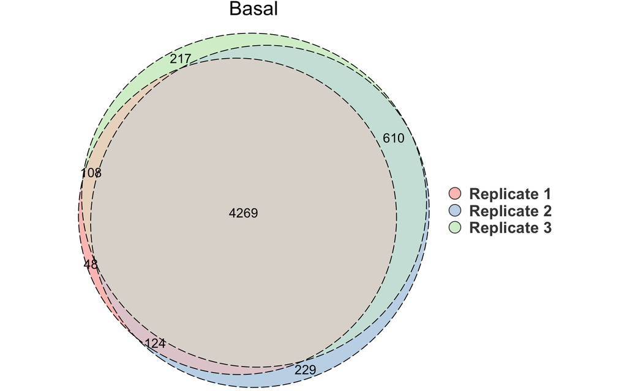

```r
## Get information for fitting of Euler
rep12_tot <- basal_tot_12 - basal_tot
rep23_tot <- basal_tot_23 - basal_tot
rep13_tot <- basal_tot_13 - basal_tot
rep1_only <- nrow(basal_prots[[1]]) - (rep12_tot + rep13_tot + basal_tot)
rep2_only <- nrow(basal_prots[[2]]) - (rep12_tot + rep23_tot + basal_tot)
rep3_only <- nrow(basal_prots[[3]]) - (rep13_tot + rep23_tot + basal_tot)

## fit and plot
fit <- euler(combinations = c("Replicate 1" = rep1_only,
                              "Replicate 2" = rep2_only,
                              "Replicate 3" = rep3_only,
                              "Replicate 1&Replicate 2" = rep12_tot,
                              "Replicate 1&Replicate 3" = rep13_tot,
                              "Replicate 2&Replicate 3" = rep23_tot,
                              "Replicate 1&Replicate 2&Replicate 3" = basal_tot),
             shape = "ellipse")
myCol <- brewer.pal(3, "Pastel1")
# myCol <- c("#66D2D6", "#FBC740", "#E56997")
plot(fit,
     edges = list(lty = 5),
     fills = list(fill = myCol, alpha = .8),
     legend = list(side = "right", font = 2, cex = 1.2),
     quantities = TRUE,
     main = "Basal")
```

```r
     # quantities = list(type = c("counts", "percent"), font = 2, cex = 1.2))
```

```r
## count proteins
insulin_tot_12 <- nrow(filterNA(MSnbase::combine(insulin_prots[[1]], insulin_prots[[2]])))
insulin_tot_23 <- nrow(filterNA(MSnbase::combine(insulin_prots[[2]], insulin_prots[[3]])))
insulin_tot_13 <- nrow(filterNA(MSnbase::combine(insulin_prots[[1]], insulin_prots[[3]])))

## insulin
insulin_p <- filterNA(MSnbase::combine(insulin_prots[[1]], insulin_prots[[2]]))
insulin_p <- filterNA(MSnbase::combine(insulin_p, insulin_prots[[3]]))
insulin_tot <- nrow(insulin_p)
paste("We find", nrow(insulin_p), "proteins in insulin")
```

```
## [1] "We find 4384 proteins in insulin"
```

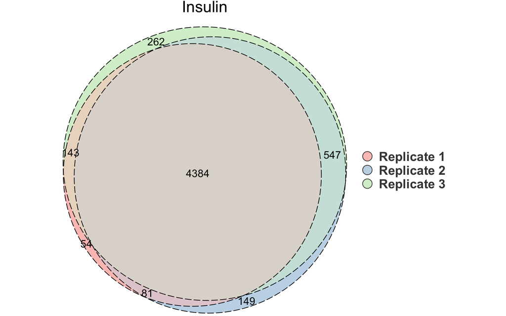

```r
## Get information for fitting of Euler
rep12_tot <- insulin_tot_12 - insulin_tot
rep23_tot <- insulin_tot_23 - insulin_tot
rep13_tot <- insulin_tot_13 - insulin_tot
rep1_only <- nrow(insulin_prots[[1]]) - (rep12_tot + rep13_tot + insulin_tot)
rep2_only <- nrow(insulin_prots[[2]]) - (rep12_tot + rep23_tot + insulin_tot)
rep3_only <- nrow(insulin_prots[[3]]) - (rep13_tot + rep23_tot + insulin_tot)

## fit and plot
fit <- euler(combinations = c("Replicate 1" = rep1_only,
                              "Replicate 2" = rep2_only,
                              "Replicate 3" = rep3_only,
                              "Replicate 1&Replicate 2" = rep12_tot,
                              "Replicate 1&Replicate 3" = rep13_tot,
                              "Replicate 2&Replicate 3" = rep23_tot,
                              "Replicate 1&Replicate 2&Replicate 3" = insulin_tot),
             shape = "ellipse")
myCol <- brewer.pal(3, "Pastel1")
# myCol <- c("#66D2D6", "#FBC740", "#E56997")
plot(fit,
     edges = list(lty = 5),
     fills = list(fill = myCol, alpha = .8),
     legend = list(side = "right", font = 2, cex = 1.2),
     quantities = TRUE,
     main = "Insulin")
```

```r
     # quantities = list(type = c("counts", "percent"), font = 2, cex = 1.2))
```

- Common proteins between conditions

```r
cmn <- commonFeatureNames(list(basal_p, insulin_p))
```

```
## 4005 features in common
```

```r
basal_cmn <- cmn[[1]]
insulin_cmn <- cmn[[2]]
paste("We find", nrow(basal_cmn), "proteins common in both conditions, across all replicates")
```

```
## [1] "We find 4005 proteins common in both conditions, across all replicates"
```

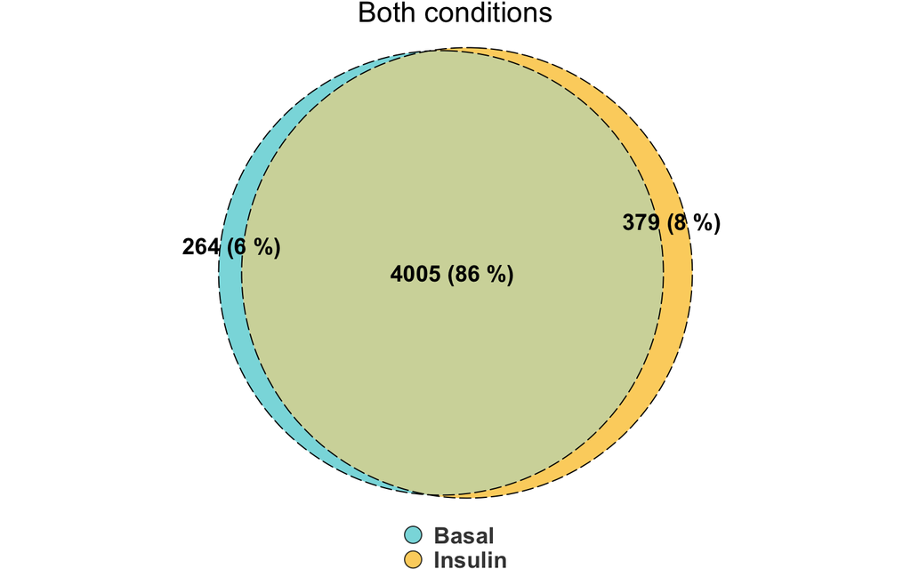

```r
## fit and plot
fit <- euler(combinations = c("Basal" = basal_tot - nrow(basal_cmn),
                              "Insulin" = insulin_tot - nrow(basal_cmn),
                              "Basal&Insulin" = nrow(basal_cmn)),
             shape = "ellipse")
myCol <- c("#66D2D6", "#FBC740")
plot(fit,
     edges = list(lty = 5),
     fills = list(fill = myCol, alpha = .8),
     legend = list(side = "bottom", font = 2, cex = 1.2),
     # quantities = TRUE,
     main = "Both conditions",
     quantities = list(type = c("counts", "percent"), font = 2, cex = 1.2))
```

# 8 Save final MSnSet objects

```r
# Individual replicates
save(basal_prots, insulin_prots,
     file = here("1_data_analysis/output/adipocyte_lopit_MSnSet.rda"))

# concatenated replicates
save(basal_p,insulin_p,
     file = here("1_data_analysis/output/adipocyte_lopit_MSnSet_concat.rda"))

# concatenated replicates, common proteins only
save(basal_cmn, insulin_cmn, cmn,
     file = here("1_data_analysis/output/adipocyte_lopit_MSnSet_cmn.rda"))
```